# MEGALECTRICS 2019 SALES REPORT

## Powered By (Market Department)

# Contents

### Report Overview

### Dataset Overview

### 2019 MONTHLY SALES

### 2019 QUARTERLY SALES

### 2019 SALES BY LOCATIONS

### 2019 AVERAGE SALES PER YEAR

### Conclusion

## Report Overview

> This is to report the Megalectrics sales for the year of 2019

## Dataset Overview

> There are 187 datas in the dataset with 17 features (STATION_NAMES, JAN_2019, FEB_2019, MAR_2019, TOTAL_1ST_QUARTER, APR_2019, MAY_2019, JUNE_2019, TOTAL_2ND_QUARTER, JULY_2019, AUG_2019, SEP_2019, TOTAL_3RD_QUARTER, OCT_2019, NOV_2019, DEC_2019, TOTAL_4TH_QUARTER).

## 2019 MONTHLY SALES

> We visualized each sale by month and each station across the board. Our observation was that out of all the stations across the board CLASSIC FM Lagos was outstanding, followed by BEAT FM Lagos. The remaining stations have fairly sales throughout each month. Only in the 1st Quarter and 2nd Quarter and a few months in 4th Quarter that stations like NAIJA FM Lagos and LAGOSTALKS FM fair more than other stations apart from CLASSIC FM Lagos and BEAT FM Lagos.

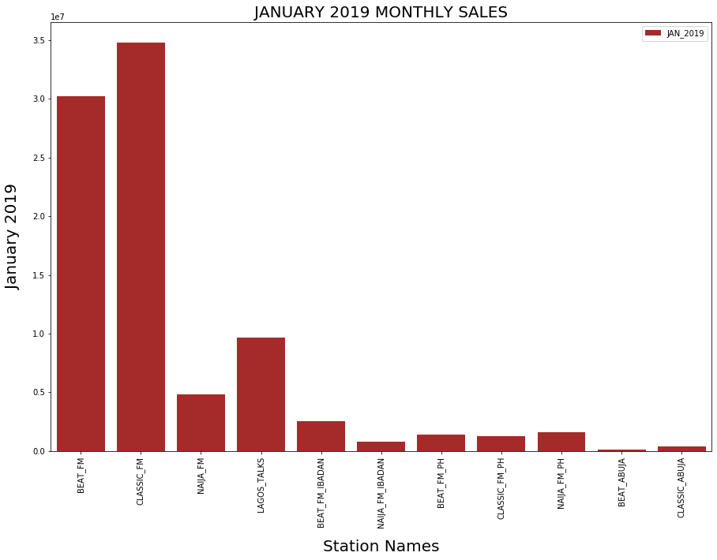

```python
sales2019.plot.bar(x="STATION_NAMES", y="JAN_2019", figsize = (15,10), color = 'brown')
plt.bar(sales2019['STATION_NAMES'], sales2019['JAN_2019'], color = 'brown');
plt.title('JANUARY 2019 MONTHLY SALES', fontsize = 20);
plt.xlabel('Station Names', fontsize = 20, labelpad=15);
plt.ylabel('January 2019', fontsize = 20, labelpad=15);
```

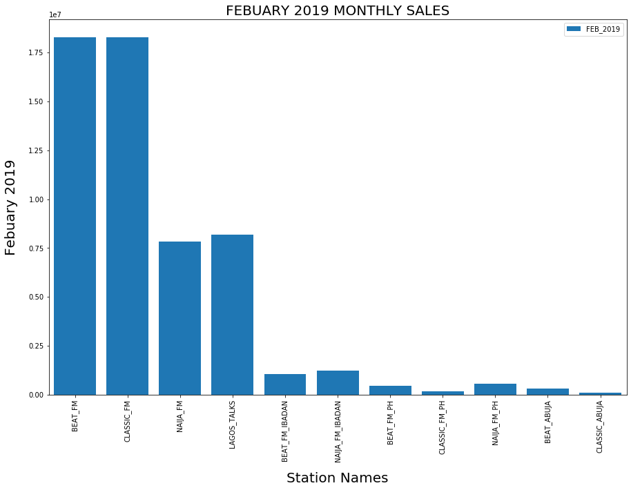

```python
sales2019.plot.bar(x="STATION_NAMES", y="FEB_2019", figsize = (15,10))
plt.bar(sales2019['STATION_NAMES'], sales2019['FEB_2019']);
plt.title('FEBUARY 2019 MONTHLY SALES', fontsize = 20);
plt.xlabel('Station Names', fontsize = 20, labelpad=15);
plt.ylabel('Febuary 2019', fontsize = 20, labelpad=15);
```

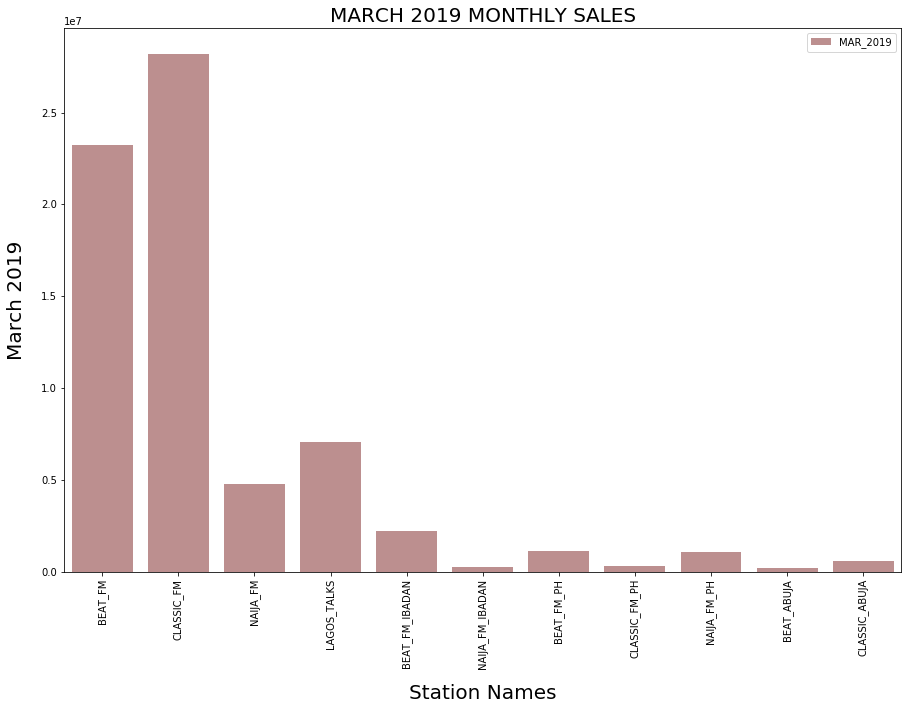

```python
sales2019.plot.bar(x="STATION_NAMES", y="MAR_2019", figsize = (15,10), color = 'rosybrown');
plt.bar(sales2019['STATION_NAMES'], sales2019['MAR_2019'], color = 'rosybrown');
plt.title('MARCH 2019 MONTHLY SALES', fontsize = 20);
plt.xlabel('Station Names', fontsize = 20, labelpad=15);
plt.ylabel('March 2019', fontsize = 20, labelpad=15);
```

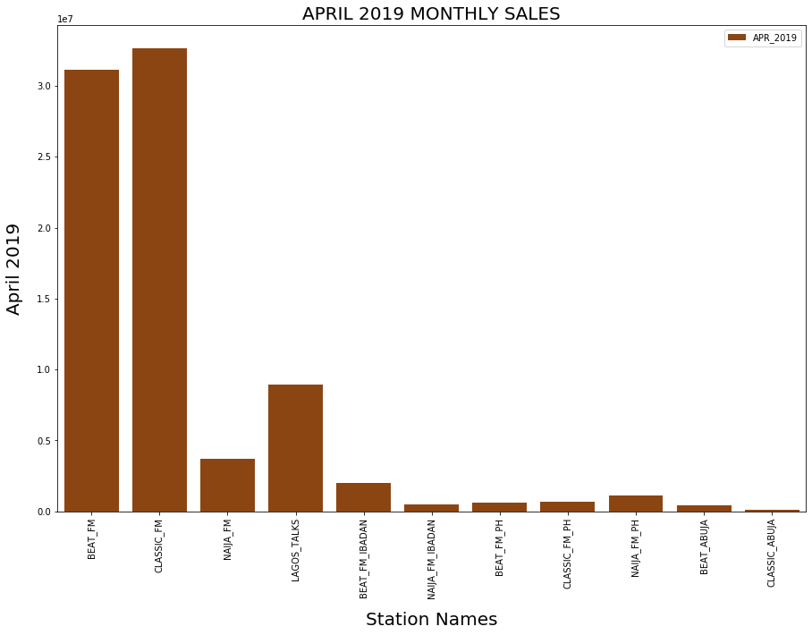

```python
sales2019.plot.bar(x="STATION_NAMES", y="APR_2019", figsize = (15,10), color = 'saddlebrown');
plt.bar(sales2019['STATION_NAMES'], sales2019['APR_2019'], color = 'saddlebrown');
plt.title('APRIL 2019 MONTHLY SALES', fontsize = 20);
plt.xlabel('Station Names', fontsize = 20, labelpad=15);
plt.ylabel('April 2019', fontsize = 20, labelpad=15);
```

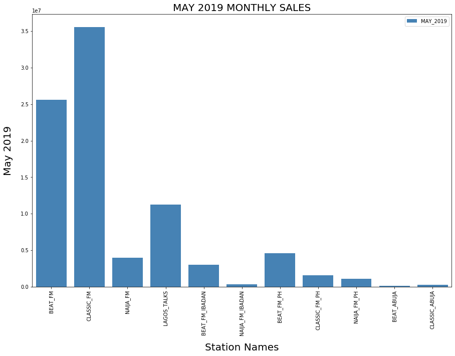

```python
sales2019.plot.bar(x="STATION_NAMES", y="MAY_2019", figsize = (15,10), color = 'steelblue');
plt.bar(sales2019['STATION_NAMES'], sales2019['MAY_2019'], color = 'steelblue');
plt.title('MAY 2019 MONTHLY SALES', fontsize = 20);
plt.xlabel('Station Names', fontsize = 20, labelpad=15);
plt.ylabel('May 2019', fontsize = 20, labelpad=15);
```

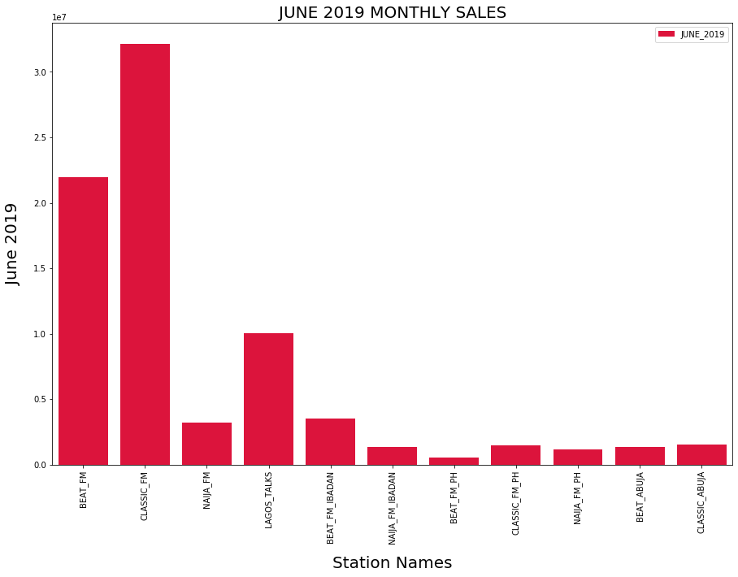

```python
sales2019.plot.bar(x="STATION_NAMES", y="JUNE_2019", figsize = (15,10), color = 'crimson');
plt.bar(sales2019['STATION_NAMES'], sales2019['JUNE_2019'], color = 'crimson');
plt.title('JUNE 2019 MONTHLY SALES', fontsize = 20);
plt.xlabel('Station Names', fontsize = 20, labelpad=15);
plt.ylabel('June 2019', fontsize = 20, labelpad=15);
```

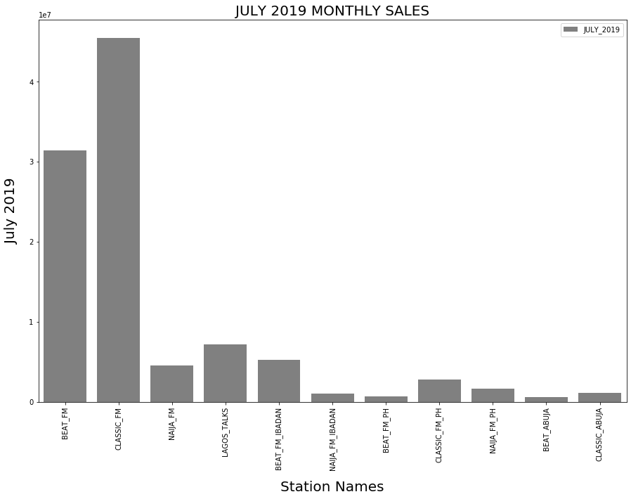

```python
sales2019.plot.bar(x="STATION_NAMES", y="JULY_2019", figsize = (15,10), color = 'grey');
plt.bar(sales2019['STATION_NAMES'], sales2019['JULY_2019'], color = 'grey');
plt.title('JULY 2019 MONTHLY SALES', fontsize = 20);
plt.xlabel('Station Names', fontsize = 20, labelpad=15);
plt.ylabel('July 2019', fontsize = 20, labelpad=15);
```

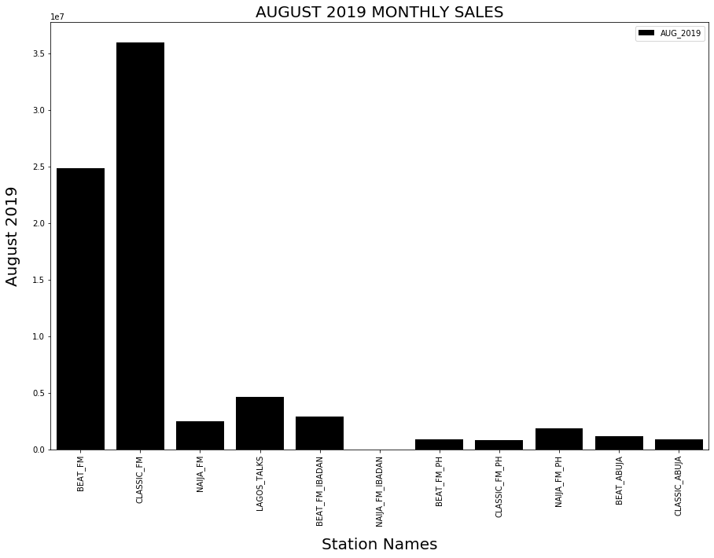

```python
sales2019.plot.bar(x="STATION_NAMES", y="AUG_2019", figsize = (15,10), color = 'black');
plt.bar(sales2019['STATION_NAMES'], sales2019['AUG_2019'], color = 'black');
plt.title('AUGUST 2019 MONTHLY SALES', fontsize = 20);
plt.xlabel('Station Names', fontsize = 20, labelpad=15);
plt.ylabel('August 2019', fontsize = 20, labelpad=15);
```

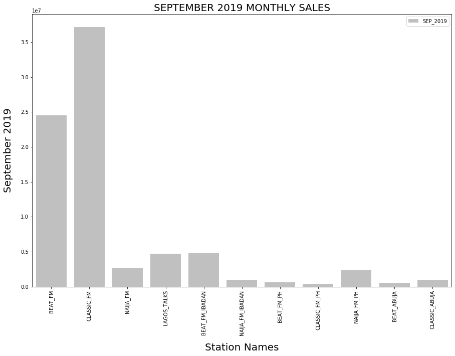

```python
sales2019.plot.bar(x="STATION_NAMES", y="SEP_2019", figsize = (15,10), color = 'silver');
plt.bar(sales2019['STATION_NAMES'], sales2019['SEP_2019'], color = 'silver');
plt.title('SEPTEMBER 2019 MONTHLY SALES', fontsize = 20);
plt.xlabel('Station Names', fontsize = 20, labelpad=15);
plt.ylabel('September 2019', fontsize = 20, labelpad=15);
```

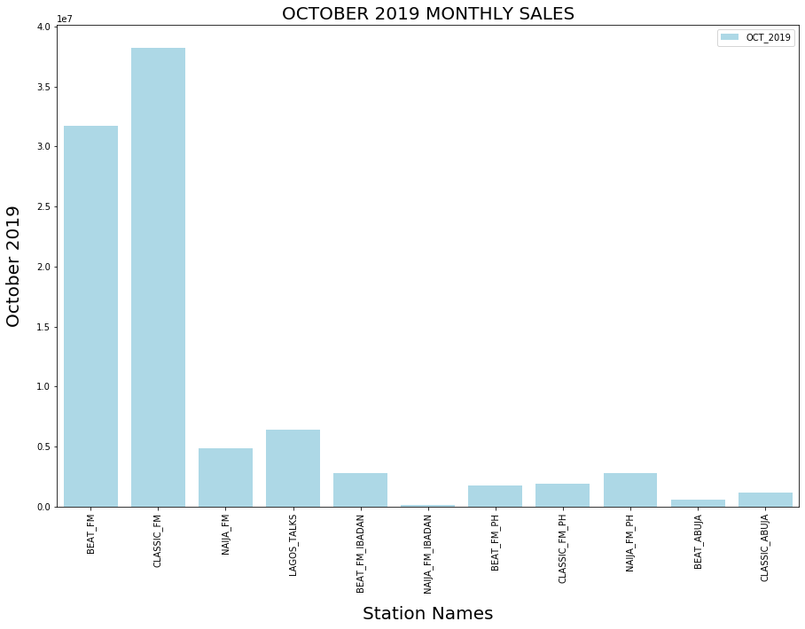

```python
sales2019.plot.bar(x="STATION_NAMES", y="OCT_2019", figsize = (15,10), color = 'lightblue');
plt.bar(sales2019['STATION_NAMES'], sales2019['OCT_2019'], color = 'lightblue');
plt.title('OCTOBER 2019 MONTHLY SALES', fontsize = 20);
plt.xlabel('Station Names', fontsize = 20, labelpad=15);
plt.ylabel('October 2019', fontsize = 20, labelpad=15);
```

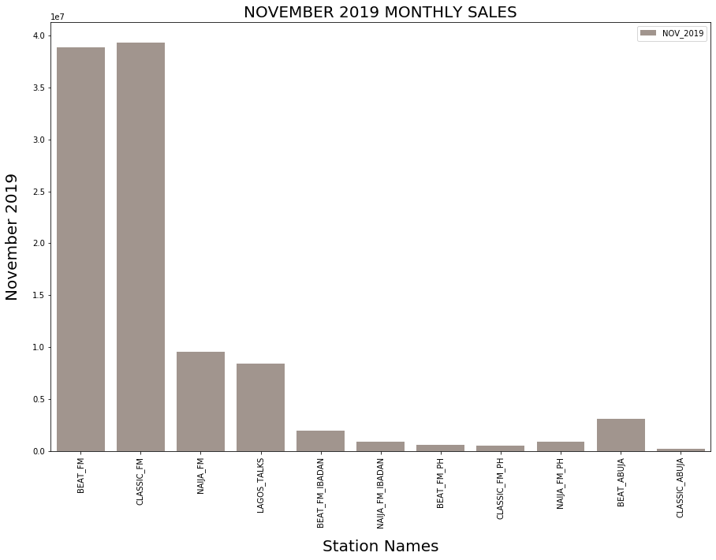

```python
sales2019.plot.bar(x="STATION_NAMES", y="NOV_2019", figsize = (15,10), color = '#a1958e');
plt.bar(sales2019['STATION_NAMES'], sales2019['NOV_2019'], color = '#a1958e');
plt.title('NOVEMBER 2019 MONTHLY SALES', fontsize = 20);
plt.xlabel('Station Names', fontsize = 20, labelpad=15);
plt.ylabel('November 2019', fontsize = 20, labelpad=15);
```

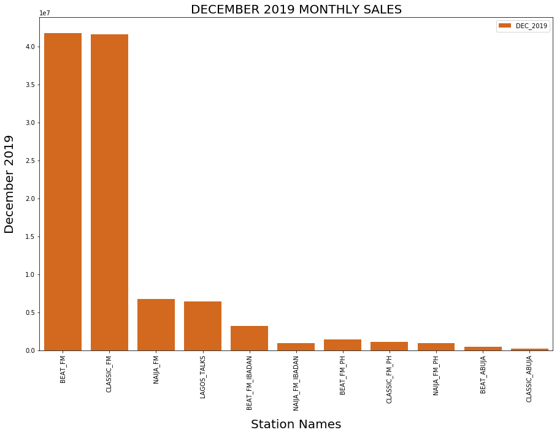

```python
sales2019.plot.bar(x="STATION_NAMES", y="DEC_2019", figsize = (15,10), color = 'chocolate');
plt.bar(sales2019['STATION_NAMES'], sales2019['DEC_2019'], color = 'chocolate');
plt.title('DECEMBER 2019 MONTHLY SALES', fontsize = 20);
plt.xlabel('Station Names', fontsize = 20, labelpad=15);
plt.ylabel('December 2019', fontsize = 20, labelpad=15);
```

## 2019 QUARTERLY SALES

> For Quarterly sales, we visualized each sale by 1st, 2nd, 3rd, and 4th quarter for each station across the board. Our observation was that out of all the stations across the board CLASSIC FM Lagos was outstanding throughout all the Quarters, followed by BEAT FM Lagos. The remaining stations have fairly sales throughout each quarter.

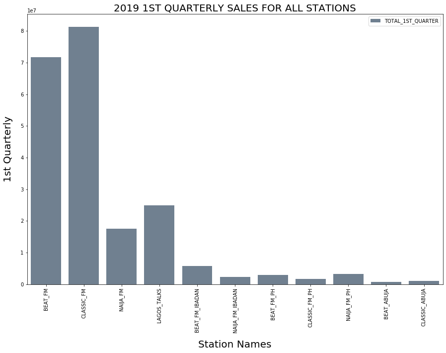

```python
sales2019.plot.bar(x="STATION_NAMES", y="TOTAL_1ST_QUARTER", figsize = (15,10), color = 'slategrey');
plt.bar(sales2019['STATION_NAMES'], sales2019['TOTAL_1ST_QUARTER'], color = 'slategrey');
plt.title('2019 1ST QUARTERLY SALES FOR ALL STATIONS', fontsize = 20);
plt.xlabel('Station Names', fontsize = 20, labelpad=15);
plt.ylabel('1st Quarterly', fontsize = 20, labelpad=15);
```

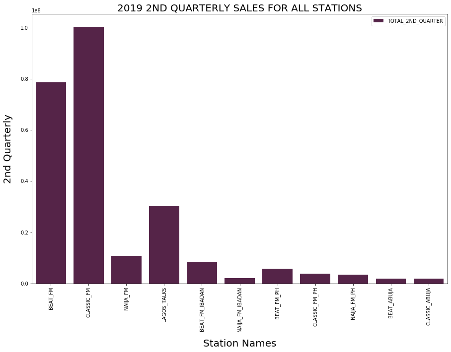

```python
sales2019.plot.bar(x="STATION_NAMES", y="TOTAL_2ND_QUARTER", figsize = (15,10), color = '#552448');
plt.bar(sales2019['STATION_NAMES'], sales2019['TOTAL_2ND_QUARTER'], color = '#552448');
plt.title('2019 2ND QUARTERLY SALES FOR ALL STATIONS', fontsize = 20);
plt.xlabel('Station Names', fontsize = 20, labelpad=15);
plt.ylabel('2nd Quarterly', fontsize = 20, labelpad=15);
```

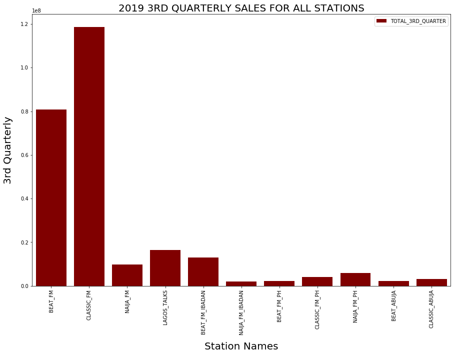

```python
sales2019.plot.bar(x="STATION_NAMES", y="TOTAL_3RD_QUARTER", figsize = (15,10), color = 'maroon');
plt.bar(sales2019['STATION_NAMES'], sales2019['TOTAL_3RD_QUARTER'], color = 'maroon');
plt.title('2019 3RD QUARTERLY SALES FOR ALL STATIONS', fontsize = 20);
plt.xlabel('Station Names', fontsize = 20, labelpad=15);
plt.ylabel('3rd Quarterly', fontsize = 20, labelpad=15);
```

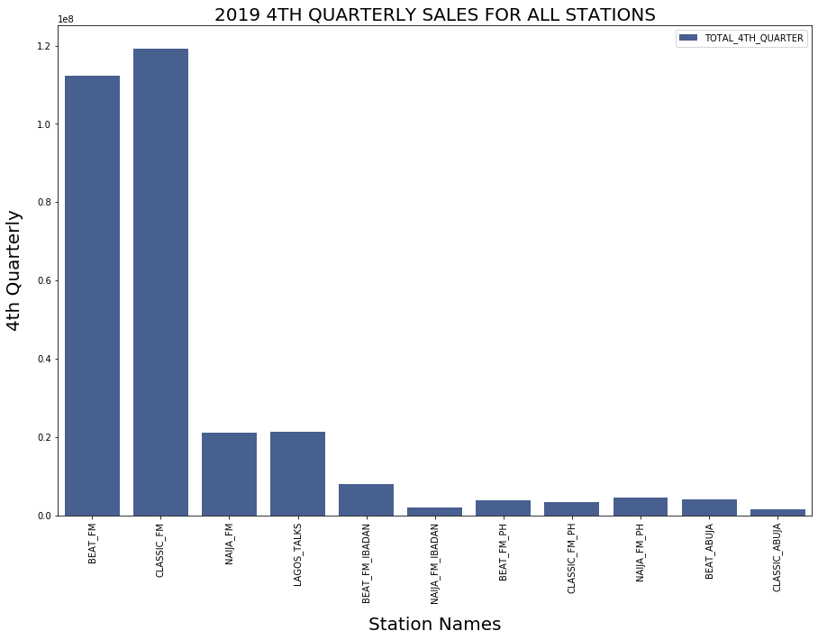

```python
sales2019.plot.bar(x="STATION_NAMES", y="TOTAL_4TH_QUARTER", figsize = (15,10), color = '#486090');
plt.bar(sales2019['STATION_NAMES'], sales2019['TOTAL_4TH_QUARTER'], color = '#486090');
plt.title('2019 4TH QUARTERLY SALES FOR ALL STATIONS', fontsize = 20);
plt.xlabel('Station Names', fontsize = 20, labelpad=15);
plt.ylabel('4th Quarterly', fontsize = 20, labelpad=15);
```

## 2019 SALES BY LOCATIONS

> Here we visualized each sale by locations (LAGOS, IBADAN, PORT-HARCOURT, AND ABUJA)for each station across the board. Our observation for the Lagos location shows that CLASSIC FM Lagos sales were much more outstanding than the rest stations in Lagos. For Ibadan location BEAT FM Ibadan performed better than NAIJA FM Ibadan. For the Port-Harcourt location NAIJA FM PH edge other stations. In Abuja location BEAT FM Abuja also performed better than CLASSIC FM Abuja.

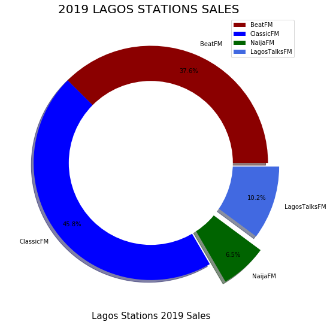

```python
my_labels=['BeatFM','ClassicFM','NaijaFM','LagosTalksFM']
my_colors=['darkred','blue','darkgreen','royalblue']
explode = (0, 0, 0.2, 0.1)
lagos_sales.plot.pie(y='LOCATION_TOTAL_SALES',autopct='%1.1f%%',figsize=(9,9),colors=my_colors,labels=my_labels,explode=explode, shadow=True, pctdistance=0.85);
plt.title('2019 LAGOS STATIONS SALES ', fontsize = 20);
plt.xlabel('Lagos Stations 2019 Sales', fontsize = 15);
plt.ylabel('');
#draw circle
centre_circle = plt.Circle((0,0),0.70,fc='white');
fig = plt.gcf();
fig.gca().add_artist(centre_circle);
```

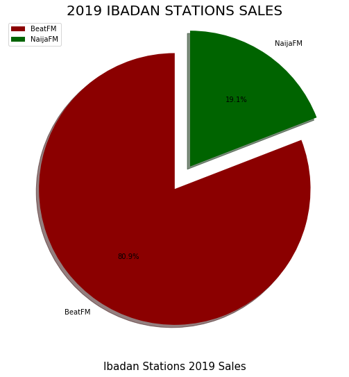

```python
my_labels=['BeatFM','NaijaFM']
my_colors=['darkred','darkgreen']
explode = (0, 0.2)
ibadan_sales.plot.pie(y='LOCATION_TOTAL_SALES',autopct='%1.1f%%',figsize=(9,9),labels=my_labels,colors=my_colors,explode=explode,shadow=True, startangle=90);
plt.title('2019 IBADAN STATIONS SALES', fontsize = 20);
plt.xlabel('Ibadan Stations 2019 Sales', fontsize = 15);
plt.ylabel('');
```

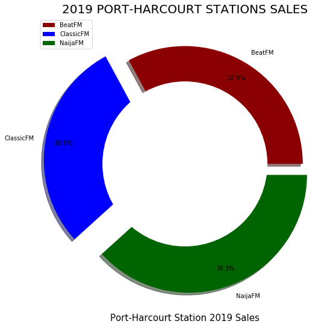

```python
my_labels=['BeatFM','ClassicFM','NaijaFM']
my_colors=['darkred','blue','darkgreen']
explode = (0, 0.2, 0.1)
ph_sales.plot.pie(y='LOCATION_TOTAL_SALES',autopct='%1.1f%%',figsize=(9,9),colors=my_colors,labels=my_labels,explode=explode, shadow=True, pctdistance=0.85);
plt.title('2019 PORT-HARCOURT STATIONS SALES', fontsize = 20);
plt.xlabel('Port-Harcourt Station 2019 Sales', fontsize = 15);
plt.ylabel('');
#draw circle
centre_circle = plt.Circle((0,0),0.70,fc='white');
fig = plt.gcf();
fig.gca().add_artist(centre_circle);
```

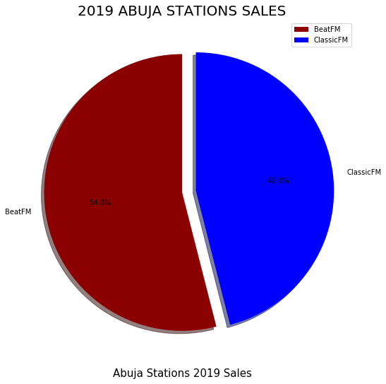

```python
my_labels=['BeatFM','ClassicFM']
my_colors=['darkred','blue']
explode = (0, 0.1)
abuja_sales.plot.pie(y='LOCATION_TOTAL_SALES',autopct='%1.1f%%',figsize=(9,9),labels=my_labels,colors=my_colors, explode=explode,shadow=True, startangle=90);
plt.title('2019 ABUJA STATIONS SALES', fontsize = 20);
plt.xlabel('Abuja Stations 2019 Sales', fontsize = 15);
plt.ylabel('');
```

## 2019 AVERAGE SALES PER YEAR

> We find the average sales for the year 2019 on all stations across the board. We have observed CLASSIC FM Lagos has an average sales of 34,957,240.00. BEAT FM Lagos has an average sales of 28,643,730.00. LagosTalks has an average sales of 7,744,778.00. Also, CLASSIC FM Abuja has the lowest average sales of 632,232.20.

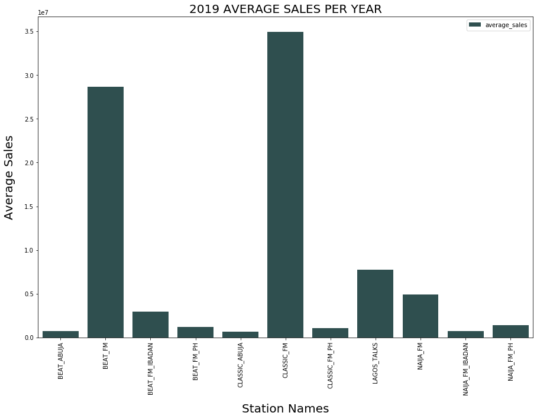

```python
avg_salesnew1.plot.bar(x="STATION_NAMES", y="average_sales", figsize = (15,10), color = 'darkslategrey');
plt.bar(avg_salesnew1['STATION_NAMES'], avg_salesnew1['average_sales'], color = 'darkslategrey');
plt.title('2019 AVERAGE SALES PER YEAR', fontsize = 20);
plt.xlabel('Station Names', fontsize = 20, labelpad=15);
plt.ylabel('Average Sales', fontsize = 20, labelpad=15);
```

## Conclusion

> The total sales for the year 2019 are 1,019,985,122.03. CLASSIC FM Lagos's total sales for the year 2019 is 419,486,911.90 and BEAT FM Lagos's total sales for the year 2019 is 343,724,781.70. The remaining stations such as LAGOSTALKS FM, NAIJA FM Lagos, BEAT FM Ibadan, NAIJA FM Ibadan, BEAT FM PH, CLASSIC FM PH, NAIJA FM PH, BEAT FM Abuja, and CLASSIC FM Abuja all shares the total sales of 256,773,428.43 for the year 2019.